# EM-IJCH230104 329..346

Converted from PDF `Haldorai-JobInsecurityCOVIDLayoffs-2024-IJCHM.pdf` · 18 pages · anchors: page `#pN`, block `#pN-bK`

Page 1

## Job insecurity and survivor workplace behavior following

## COVID-19 layoff

Kavitha Haldorai and Woo Gon Kim International Center for Hospitality Research and Development, Dedman College of Hospitality, Florida State University, Tallahassee,

### Florida, USA, and Kullada Phetvaroon Faculty of Hospitality and Tourism, Prince of Songkla University Phuket Campus,

Phuket, Thailand

Abstract Purpose – This study aims to investigate the impact of job insecurity (JI) on employee work performance (WP) and service innovation behavior (SIB). It further examines the mediating role of affective commitment (AC) and the moderating role of organizational cynicism and financial job dependence (FJD).

Design/methodology/approach – By using a three-wave approach, the hypotheses were tested by collecting data from 473 full-time employees and their supervisors in the Thai hotel industry.

Findings – The results demonstrated that JI negatively affected WP and SIB. AC mediated these relationships. FJD moderated these relationships such that at high levels of job dependence, the negative relationships were weaker.

Research limitations/implications – Human resource managers may reduce the negative effects of JI by creating a supportive and caring work environment through open communication. They may communicate openly with employees about the challenges the organization is facing, and involve them in planning, decision-making and implementation to mitigate the negative effects of JI. They may also provide training and development opportunities to help employees build their skills and increase their value to the organization.

Originality/value – Research on the behavioral consequences of JI is scant in the hospitality sector. Drawing on job–demand resource theory, this study attempts to fill this gap.

Keywords Job insecurity, Affective commitment, Work performance, Service innovation behavior, Organizational cynicism, Job dependence

Paper type Research paper

1. Introduction Innovation is essential for business resilience and allows businesses to maintain a competitive advantage. In the hospitality industry, continuous service innovation is the key to establishing differentiation and retaining customers. Innovative service contributes to improved service quality, helps to meet customers’ unique service demands and increases customer satisfaction (Yang et al., 2021). They defined service innovation behavior (SIB) as the generation and promotion of new and useful service ideas by employees, aimed at enhancing service quality. Employees’ innovative behavior contributes significantly to service firms’ performance and long-term survival (Li and Hsu, 2016). Several studies have documented the positive outcomes associated with employees’ innovative behavior as well as the factors that positively influence

### Survivor workplace

### behavior

### 329

Received 5 March 2022

Revised 8 June 2022

7 October 2022 24 January 2023 19 March 2023 Accepted 26 March 2023

International Journal of Contemporary Hospitality

Management Vol. 36 No. 1, 2024

pp. 329-346 © EmeraldPublishingLimited

0959-6119 DOI 10.1108/IJCHM-03-2022-0289

The current issue and full text archive of this journal is available on Emerald Insight at: https://www.emerald.com/insight/0959-6119.htm

Page 2

innovative behavior in the hospitality industry (Yang et al., 2021). There are, however, few studies that have explored the factors that hinder innovative behaviors (Lori et al., 2003). Research suggests that it is equally important to identify the negative factors in the workplace that stifle innovative behavior (Li and Li, 2022). Accordingly, scholars have called for further studies on the job stressors that prevent innovative behavior. This study examines the impact of job insecurity (JI), as a job stressor, on SIB. Li and Li (2022) noted that the relationship between JI and innovative behavior is not clear, and there is no consensus on how they are related. Therefore, it is necessary to explore the relationship between them from a variety of perspectives to fully understand it.

It is important to understand the relationship between JI and SIB for various reasons. JI, defined as the perceived threat of losing one’s job (De Witte, 1999), is becoming increasingly inescapable, through rapid changes in the organizational environment and increasing nonstandard employment arrangements. Furthermore, in the hospitality industry, the accelerating pace of organizational change, increasing competitive pressures and the increase in mergers and acquisitions have forced organizations to improve effectiveness and streamline operations through downsizing, outsourcing and restructuring. These actions are often associated with workforce reduction, and at the employee level, these changes create the feeling of JI (De Cuyper et al., 2020; Karatepe et al., 2022). Additionally, several past studies have documented that JI is one of the most powerful stressors closely associated with the hospitality industry (Etehadi and Karatepe, 2019; Xiao et al., 2022). This condition has been further aggravated by the COVID-19 pandemic and economic turmoil, as the hospitality industry is particularly vulnerable to shocks such as an epidemic outbreak (Pillai et al., 2021). Considering this context of uncertainty, understanding employee perceptions of JI and how those perceptions impact SIB, is important. Moreover, past studies have explored the link between JI and work performance (WP), and have found inconsistent results (Shoss, 2017; Sverke et al., 2019). As WP is a key concern for managers, obtaining a better knowledge of the JI–performance link can aid organizations in better managing stress reactions and supporting organizational success. Consequently, Nikolova et al. (2022) called for further research investigating the impact of JI on different types of performances that have important strategic implications for organizations. Therefore, to have a complete account of employee performance, this study examines the relationship between JI and WP (“in-role” performance) and SIB (“extra-role” performance).

Additionally, there is also a lack of knowledge on why JI may have negative effects on work outcomes and when these negative effects are mitigated or strengthened. In particular, Xiao et al. (2022) called for further research on JI and the emotions that accompany it. Therefore, this study also examines the psychological mechanism underlying performance responses to JI. Xiao et al. (2022) have also emphasized the identification of potential moderators that affect JI and individual reactions to that insecurity. JI and the outcomes it manifest may be moderated by situational factors such as “financial job dependence (FJD),” which is caused by a lack of employability and economic need. A high rate of unemployment in Thailand may promote job dependency under conditions of low unemployment benefits, and high cultural value attached to job security (Haldorai et al., 2020). Employees who are financially dependent on their jobs may continue to exhibit high levels of performance to secure their jobs in comparison to those who are less financially dependent on their jobs. However, to date, there are only two studies focusing on the moderating role of job dependence (Richter et al., 2014; Sora et al., 2010). Similarly, Aslam et al. (2016) noted that employees are more prone to express anger, antagonism and cynicism toward their organization when they sense a psychological contract violation created by danger to their job security. They noted that studies examining the moderating role of organizational

### IJCHM 36,1

### 330

Page 3

cynicism (OC) in the context of organizational change and JI are rare. In sum, this study examines whether JI impairs job performance, why and for whom as shown in Figure 1.

2. Theoretical background and hypotheses 2.1 Job Demands–Resources theory The core premise of the Job Demands–Resources (JD-R) model (Demerouti et al., 2001) is that working conditions, which are unique to each occupation, can be characterized as either job demands or job resources (Bakker and Demerouti, 2007). As a result, the JD-R model may be used in a variety of organizational contexts to investigate the effects of distinct work environments on employee work outcomes. Job demands are the physical, psychological, social or organizational components of a job that need constant physical or mental effort and are linked to physiological and psychological consequences (Demerouti et al., 2001). On the other hand, job resources are the physical, psychological, social and organizational characteristics of the job that can favorably help the attainment of work goals, reduce job demands or encourage personal growth and development (Demerouti et al., 2001). JD-R is a promising framework for investigating the impact of JI on individual and organizational outcomes (Darvishmotevali et al., 2017; Karatepe et al., 2022). Despite the fact that the JD-R model has been used to describe a wide range of organizational phenomena, research has yet to completely integrate JI literature into this model. JI as a form of job demand and stressor can interfere with employee work outcomes. The resources used to deal with the job demands associated with JI might be psychological, such as boosting affective commitment (AC) to lower cynicism toward the organization.

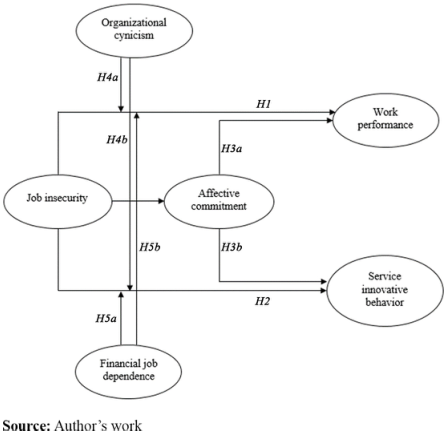

NOTE: figure/graphic rendered as an image from the PDF; its content is not machine-readable text. Caption (if any) follows as the next block.

Figure 1. Proposed framework

### Survivor workplace

### behavior

### 331

Page 4

2.2 Job insecurity and work performance JI is a threat to employees because it indicates the possibility of an involuntary shift in employment that can happen in both secure and insecure organizations (Darvishmotevali et al., 2017; Karatepe et al., 2022). Hellgren et al. (1999) suggested “qualitative” and “quantitative” aspects of JI. “Qualitative JI” refers to perceived threats to the value-added aspects of the job (e.g. deteriorating job conditions, limited opportunities to advance). “Quantitative JI” refers to concerns about losing one’s job and its valued features (e.g. loss of insurance, wage reduction). Both aspects of JI affect employee attitudes and behavior. Our study investigates the outcomes of JI from a quantitative perspective. In general, WP refers to how well an employee performs his/her task, role, job or responsibility. WP includes two interplaying components, namely, “task performance” and “contextual performance.” “Task performance” refers to an employee’s core job responsibilities. It is also called “in-role prescribed behavior” (Koopmans et al., 2011), and it is evident in work outcomes and deliverables, along with the quality and quantity the employee provides. “Contextual performance,” also known as “discretionary extra-role behavior” (Koopmans et al., 2011), transcends formal job responsibilities and includes activities such as coaching co-workers, building organizational social networks and going above and beyond the call of duty. In this study, WP is operationalized as task performance.

Based on the JD-R framework, job demands predict negative work strain in the workplace (Bakker and Demerouti, 2007). Job demands are those aspects of the job that cause strain (Demerouti et al., 2001). Job demands can be classified as “challenge” demands or “hindrance” demands (Cavanaugh et al., 2000). Despite their energy-depleting nature, “challenge” demands are conducive to achieving goals and developing personal skills (e.g. cognitive demands), whereas “hindrance” demands are those that prevent employees from achieving their goals (e.g. JI) (Haldorai et al., 2022). JI is considered a “hindrance” demand because it creates uncertainty (De Witte, 1999), and it will continue to deplete employees’ physical and psychological resources as long as the sources of uncertainty persist (Demerouti et al., 2001). Researchers who assert that JI has a negative effect on behavioral outcomes consider JI to be a hindrance stressor that drives undesirable behavior (Darvishmotevali et al., 2017; Nikolova et al., 2022). To emotionally cope with such stressors, individuals tend to behaviorally withdraw from these situations. Behavioral withdrawal can manifest as reduced “in-role” and “extra-role” performance in the workplace. For instance, Shin and Hur (2021) found that JI negatively impacted work outcomes. Consistent with these studies, and adopting the JD-R lens, we propose the following:

H1. “JI negatively affects WP.”

2.3 Job insecurity and service innovation behavior Innovative behavior is defined as the “deliberate adoption of new and improved ideas, processes, practices, and policies aimed at increasing organizational effectiveness, achieving business success, and ensuring long-term sustainability” (Anderson et al., 2014, p. 1320). The study by Amabile and Conti (1999) on the impacts of downsizing on employee creativity is the earliest research investigating factors related to JI and employee innovative behavior. They observed that organizational downsizing significantly deteriorated innovative behavior among employees. Probst et al. (2007) investigated the direct association between JI and creativity through a series of field and laboratory investigations. They found that the study participants who had been manipulated with layoff threats were poor at the “Duncker creative problemsolving task” when compared with their control-group (no-layoff) peers. When replicating these direct relationships, Niesen et al. (2018) and Van Hootegem et al. (2019) found comparable

### IJCHM 36,1

### 332

Page 5

results. These results imply that employees who fear losing their jobs are unable to commit their time and energy to developing and implementing creative ideas in service operations. Furthermore, Etehadi and Karatepe (2019) showed that JI negatively influences SIB among hospitality employees. Hence, it is hypothesized that:

H2. “JI negatively impacts SIB.”

2.4 Mediating role of affective commitment AC reflects an employee’s loyalty to his/her organization. Affectively committed employees are motivated by a strong sense of belongingness and identification that boosts their willingness to be involved in the organization’s activities and accomplish the organization’s goals, as well as their desire to remain with the organization (Meyer et al., 2002). From the JD-R perspective, employee resources are threatened by the loss of employment, income and status as a result of JI. When employees face the threat of potential job loss, it results in a negative attitude toward supervisors, the organization and the work itself (Jiang et al., 2019). Individuals who experience JI are less likely to feel a sense of belongingness and obligation to the organization. Sverke et al. (2002) contended that JI is a stressor that is negatively related to commitment. When the potential survival of an employee is uncertain, he/she is more likely to question the extent to which the organization will continue to value their contribution (Kong et al., 2021). These perceptions lower their AC toward their organization. On the other hand, AC is a critical precursor to both “in-role” and “extra-role” behaviors (Meyer et al., 2002). In agreement with this view, studies have established a link between AC and WP (Sharma and Dhar, 2016). Affectively committed employees display innovative work behavior by taking risks, and they thrive on the challenge to give aid to their organizations (Bak, 2020). Specifically, Kong et al. (2021) found that committed employees go the extra mile to come up with innovative service ideas to promote organizational competitiveness in the hospitality industry. Taken together, JI is negatively related to WP and SIB through lowered AC. Hence, it is hypothesized as follows:

H3. “AC mediates the relationship between JI and (a) WP and (b) SIB.”

2.5 Moderating role of organizational cynicism Cynicism, in its simplest form, is detesting and distrusting others. OC occurs when employees perceive that their organization lacks integrity, is evasive and cannot be trusted to keep its promises. Dean et al. (1998, p. 345) defined OC as “a negative attitude toward one’s employing organization, comprised of three dimensions: a belief that the organization lacks integrity; negative affect toward the organization; and tendencies to disparaging and critical behaviors toward the organization that are consistent with these beliefs and affect.” Taking these three dimensions together, OC essentially occurs as a complex attitude anchored in employee “cognitions, emotions, and behavioral” tendencies concerning the organization’s lack of integrity. Sometimes, cynicism may arise as a result of repeated moral contract transgressions and in other cases a single episode may be sufficient to develop a cynical attitude. Dean et al. (1998) further noted that, once developed, cynicism may be brandished against top management, supervisors, patrons, colleagues and the organization as a whole.

JI has a strong negative impact on WP and SIB for employees who are highly cynical. That is, employees who are highly cynical compared to their counterparts believe that they are in an organization that is facing serious problems that will not be resolved because of self-centered

### Survivor workplace

### behavior

### 333

Page 6

decision-makers, obstinate managers and uncooperative employees (Jiang et al., 2019). As a result, highly cynical employees are suspicious of the intent, acts and values of the organization and its members. Moreover, they feel frustrated, hopeless, disillusioned, contemptuous, distressed, disgusted, angry and even ashamed when thinking about their organization (Collins, 2017). As a consequence of these negative cognitions and affective experiences, JI is more likely to have a negative impact on WP and SIB for highly cynical employees, as this is consistent with their cynical attitudes. In contrast, the negative impact of JI on WP and SIB may be less obvious among low-cynicism employees, who believe that their organization is genuine, honest, trustworthy, supportive and cooperative (Neves, 2012). As a result of these positive cognitions, low-cynicism employees are less likely to display reduced WP and reduced SIB when experiencing JI, as this contradicts their relatively positive perceptions of the organization. Furthermore, employees with a highly cynical attitude remain vigilant, scanning the organization for signs of hypocrisy and potential threat (Collins, 2017). Having a highly cynical attitude can cloud the lens through which employees see their workplace. Hence, highly cynical employees may regard layoffs as being unfair, leading to retaliation in various forms including lowering their work effort and innovative behavior. On the other hand, employees less inclined to cynicism will be less distrustful of events that occur in their workplace. These employees are better able to understand the challenges their organization is facing and may consider JI at face value, and thus these employees may not reduce their in-role performance and innovative behavior. Furthermore, job security is considered an important obligation that employees believe their organization should fulfil (Shoss, 2017). When they are dissatisfied with the level of job security, highly cynical individuals believe that their organization has failed to live up to the obligations it has to its employees. Highly cynical employees who experience JI become suspicious of the organization and its objectives and are more likely to display lower performance and innovative behavior compared to low cynicism employees. Research suggests that employees reporting higher levels of OC are unlikely to exceed the bare minimum of performance when experiencing any kind of uncertainty and mistreatment from their organization (Neves, 2012). The highly cynical also display minimal levels of innovative behavior because of distrust in their organization’s decisions and actions (Aslam et al., 2016). Therefore, we hypothesize as follows:

H4. “OC moderates the negative relationship between JI and (a) WP and (b) SIB, such

that the relationship is stronger among employees with a high OC compared to those with a low OC.”

2.6 Moderating role of financial job dependence Despite previous research findings demonstrating that JI negatively impacts employee work attitudes and behavior, some aspects of this relationship remain unclear. A meta-analysis by Sverke et al. (2002) revealed inconsistent findings across previous studies. They noted that the findings of the studies differed greatly in relation to JI and its consequences. In light of these inconsistencies, Sverke et al. (2002) concluded that other factors may have a role in the link between JI and its consequences. Xiao et al. (2022) posited that individual differences might moderate the link between JI and individual reactions. Additionally, situational variables might also affect whether JI is perceived as a more or less serious threat, and that in turn could influence the severity of the consequences. In this case, the FJD of employees in their current job can be viewed as a situational variable that can have a moderating effect.

FJD refers to reliance on a job because of the resources the job offers to an individual (e.g. salary). Reactions to JI are largely determined by job dependency (Richter et al., 2014; Sora et al., 2010). The threats posed by JI are exacerbated at high levels of income insecurity

### IJCHM 36,1

### 334

Page 7

(Chua et al., 2022). From a job preservation motivation perspective (Shoss, 2017), those employees who are economically vulnerable or have a high dependence on their job for financial security (i.e. high FJD) are inclined to protect their employment because they believe it will be more difficult to replace the job and/or income if it is lost. That is, individuals who are economically insecure, or those individuals who believe they will not be able to meet their living expenses if they lose their current job, take active measures to prevent job loss. As an active job preservation strategy, employees try to portray themselves as an ideal employee by enhancing their task performance and extra-role performance. Economically insecure employees believe that their heightened performance will improve their chance of continued employment when experiencing JI (Brockner et al., 1987). These employees also use persuasive strategies, like getting involved in extra-role behavior, such as innovative behavior, to draw attention to their abilities, as they believe extra-role performance is instrumental in securing one’s job. Taking these assertions together with a job preservation motivation perspective (Shoss, 2017), we believe that the detrimental effects of JI on WP and SIB are less prominent among employees with higher FJD than those with lower FJD. For instance, Richter et al. (2014) found that the experience of high job dependence did not exacerbate the negative association between JI and work attitude (job satisfaction). On the other hand, employees with low job dependence reacted more negatively to JI. Similarly, Sora et al. (2010) showed that for employees with income security and thus reduced economic vulnerabilities (reflecting low FJD), the negative association between JI and job attitudes was stronger than their counterparts who had no access to these benefits. Therefore, we hypothesize as follows:

H5. “The negative impact of JI on (a) WP and (b) SIB is moderated by FJD such that the

negative relationship is stronger for those with low FJD rather than high FJD.”

3. Methodology 3.1 Samples and procedure The study participants included full-time Thai hotel service employees who survived COVID-19 layoffs and their supervisors. First, one of the research team members contacted the human resource (HR) managers of the hotels in Phuket to explain the study’s goal. Out of the 35 contacted hotels, 18 hotels consented to take part in our study. Out of those 18 hotels, 8 were classified as luxury hotels, 7 were upscale and 3 were mid-scale hotels. With the help of the HR managers, one of the study team members personally visited each property to distribute the survey packets to the diverse spectrum of employees who consented to participate. We invited only those service employees who had survived COVID-19 layoffs. We distributed 40 survey packets to each of the 8 luxury hotels, 30 to each of the 7 upscale hotels, and 20 survey packets to each of the 3 mid-scale hotels. In sum, we distributed 590 survey packets. The survey packets included the survey instrument, the survey completion procedure, information on the anonymity and confidentiality of the responses and a self-adhesive return envelope. On completion, the surveys were placed in the return envelopes and the respondents were instructed to drop them into the locked drop boxes that were placed near the reception desk at each property.

We conducted the study in three waves by collecting data from the employees during the first-wave (T1) and the second-wave (T2) and from their supervisors during the third-wave (T3). At T1, the employees provided the responses for JI (independent variable), their background information and their psychological attachment with a laid-off victim. At T2, data was collected for the mediator (AC) and the moderators (OC and FJD), and at T3 the supervisors rated their employees’ WP and SIB. The data was collected during September– November 2020 (T1), January–March 2021 (T2) and May–July 2021 (T3). We received 261

### Survivor workplace

### behavior

### 335

Page 8

surveys from luxury hotels, 170 from upscale hotels and 58 from mid-scale hotels. Out of the 489 surveys, 481 surveys were usable from T1. During T2, we approached these 481 employees, and, after matching the T1 and T2 responses, 476 responses were usable. At T3, questionnaires were distributed to the supervisors of these 476 employees. After matching the responses, 473 usable responses were recorded. Attrition bias occurs “if participants who stay in a study differ from those who drop out” (Gustavson et al., 2012, p. 1). As only a few respondents dropped out from the subsequent waves, following Gustavson et al. (2012), we requested that the supervisors examine the characteristics of participants and nonparticipants in the subsequent surveys. The supervisors stated that the participants and non-participants were demographically similar. Of the 473 participants with a mean age of 37 years, 30% are male and 70% are female. The mean experience in the current hotel and the hotel industry was 7.5 and 14 years, respectively. Regarding their education, 70% of the respondents had earned a four-year degree, 26% had a two-year degree and 4% had a master’s degree. Regarding department affiliation, 32% belonged to the front office, 38% were from food and beverage and 30% were from housekeeping.

3.2 Measures Multi-items from previous similar research were used to measure all constructs. A higher score reflects a higher level of each construct. A back-translation was used to translate measurements originally in English into Thai. Prior to initiating the data collection procedure, two pilot samples of ten employees were used to test the employee surveys (T1 and T2). The supervisor survey was pretested with the assistance of five supervisors. The participants reported no difficulty in reading and understanding the items, so no amendments were necessary. The respondents responded on a five-point scale ranging from 1 (strongly disagree) to 5 (strongly agree) for all constructs except psychological attachment with a laid-off victim.

JI was measured with a three-item scale from Hellgren et al.’s (1999) quantitative JI scale. AC was assessed using Meyer et al.’s (1993) six-item scale. Five items developed by Brandes et al. (2008), using the theoretical definition proposed by Dean et al. (1998), were used to measure OC. FJD was measured by four items developed by Richter et al. (2014). The sevenitem job performance scale developed by Williams and Anderson (1991) was used to measure employees’ overall WP. Employee SIB was measured with a six-item scale from Hu et al. (2009). Two items from Brockner et al. (1987) measured survivors’ prior attachment to the layoff victims. These two items were rated on a seven-point Likert scale ranging from “not at all close” (1) to “very close” (7).

3.3 Control variables Age, gender, tenure in the current hotel, tenure in the hotel industry, education level and hotel classification were treated as control variables to rule out potentially spurious relations (Karatepe et al., 2022). Additionally, prior studies have documented that layoff survivors react more severely to layoffs, JI and downsizing when they are close or psychologically attached to the layoff victims (Brockner et al., 1987). Therefore, we also collected employee responses to psychological attachment with a laid-off victim and controlled it. As the control variables did not affect the results significantly, we report the results without the control variables.

3.4 Common method bias To control for method bias, precautions were taken during the study’s design following the suggestions of Podsakoff et al. (2003). We obtained the measures of the independent and

### IJCHM 36,1

### 336

Page 9

outcome variables from different sources. The responses to the predictor variables were collected from the employees and the responses to the outcome variables were provided by the employees’ respective supervisors. Additionally, we also created temporal separation by introducing a time lag between the measurement of the predictor and the outcome variables. Next, the participants were assured that there are no right or wrong responses and that they should be as honest as possible while answering questions. This procedure is likely to reduce respondents’ evaluation apprehension and make them less likely to alter their responses to be more socially acceptable. Furthermore, using PLS the results from the full collinearity test were below 3.3, indicating the models were free of common method bias (Kock, 2015).

4. Results 4.1 Reliability and validity As the supervisors rated the employees’ WP and SIB, there is a possibility that the supervisor’s rating of more than one subordinate creates a nested effect. However, the ANOVA results were not significant. Therefore, we can be conclude that the supervisors’ ratings were relatively independent and did not significantly influence the study’s outcomes. Hair et al. (2017) recommended evaluating the loadings, average variance extracted (AVE), composite reliability (CR) and Dijkstra-Henseler (rA) to test the convergent and the discriminant validity. As displayed in Table 1, the loadings are above 0.7, AVEs are greater than 0.5 and CRs are above 0.7, thus indicating that the measures were both valid and reliable. We used Fornell and Larcker’s criterion and Heterotrait–Monotrait (HTMT) criterion to evaluate discriminant validity. Discriminant validity is established if the square root of the AVE exceeds all the correlations in the same row and column of the specific construct. The HTMT values were reported in Table 2, and all were under a 0.9 threshold, indicating evidence of discriminant validity. In sum, as portrayed in Table 2, discriminant validity of the constructs was achieved.

### Survivor workplace

### behavior

### 337

Page 10

5. Discussion and conclusion 5.1 Conclusion Under the unexpected changes caused by COVID-19, the study sought to shed light on the effects of JI on WP and SIB. The study further examined the mediating role of AC and the

Table 1. Loadings and reliability

[output not shown]

NOTE: table converted from PDF layout to HTML text; cell boundaries are reconstructed. See PDF if exact alignment matters.

Page 11

moderating role of OC and FJD. From the JD-R perspective, stable employment is viewed as a valuable resource, and the threat of losing that employment has a detrimental impact on employees’ work attitude and behavior. Furthermore, the results suggested that an increased perception of JI lowered AC, which in turn negatively affected employees’ WP and their SIB. Finally, FJD moderated the negative relationship between JI and its outcomes. In particular, at heightened insecurity levels and with low financial dependency, employees’ WP and SIB were low. The economic hardship of losing a job can be especially distressing to an employee who has high financial demands. From a job preservation motivation perspective, such employees are motivated to increase their WP and innovative behavior when such performance is, or is assumed to be, instrumental toward securing their job.

5.2 Theoretical contributions The findings contribute significantly to the corpus of knowledge in several ways. Research on the behavioral consequences of JI in the tourism and hospitality sector has been scarce to date (Khan et al., 2022). Additionally, De Cuyper et al. (2020) and Sverke et al. (2019) noted that the majority of studies on JI are from Europe or the USA and have accordingly called for further research. To address these gaps, the study investigated the impact of JI on hotel

Table 2. Discriminant validity

[output not shown]

NOTE: table converted from PDF layout to HTML text; cell boundaries are reconstructed. See PDF if exact alignment matters.

Notes: Values in italic are the square root of AVEs. Below the diagonals are the correlation values; Above the diagonals are HTMT values Source: Author’s work

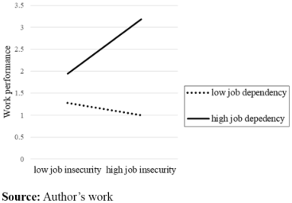

NOTE: figure/graphic rendered as an image from the PDF; its content is not machine-readable text. Caption (if any) follows as the next block.

Figure 2. Moderating effect of

FJD on the relationship between

JI and WP

### Survivor workplace

### behavior

### 339

Page 12

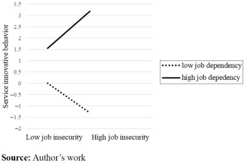

NOTE: figure/graphic rendered as an image from the PDF; its content is not machine-readable text. Caption (if any) follows as the next block.

Second, studies that examine mediating constructs between JI and its outcomes have gained a substantial amount of attention. Our research responds to a call for theoretical explanations for contradictory findings on the work insecurity–performance relationship, as highlighted in recent JI reviews (De Cuyper et al., 2020; Shoss, 2017). To accomplish this, we examined the mediating role of AC in the link between JI and its behavioral

Figure 3. Moderating effect of FJD on the relationship between JI and SIB

Table 3. Summary of results

[output not shown]

NOTE: table converted from PDF layout to HTML text; cell boundaries are reconstructed. See PDF if exact alignment matters.

### IJCHM 36,1

### 340

Page 13

outcomes. The findings add to AC literature by suggesting JI as an antecedent to AC. Furthermore, the relationship between JI and workplace behavior conforms to Ortony et al.’s (1988) cognitive processes theory involving the generation of emotions. The proposed research model in this study is built on an emotional trigger that flows from an employee’s perception of JI. Cognitive evaluation of this perception (Ortony et al., 1988) leads to an emotional reaction, such as lowered AC, that further affects work behavior.

A third key contribution of this study is the role of FJD. To examine employees working in an extreme and uncertain environment, this study was carried out in Thailand following the COVID-19 outbreak. The study results revealed the influence of employees’ FJD on the relationship between JI and its consequences. Furthermore, given the high levels of volatility experienced by hotel frontline employees, this study offers a fairly rigorous examination of employees’ experiences in a challenging environment (such as during COVID-19, economic crisis or natural catastrophes). The COVID-19 pandemic created a new situation, particularly for service employees (Liu-Lastres et al., 2023). Such outbreaks being contagious, pose additional challenges for employees who have direct contact with customers. They involve immediate threats to frontline employees facing changing shutdown and social distancing protocols, in addition to furloughs and layoffs in workplaces. Given the catastrophic effects of the COVID-19 pandemic on frontline workers and the disruption to their daily schedules, it is critical to understand the evaluation, emotion and behavior of employees during these occurrences. Therefore, our study in the context of the workplace allowed us to ascertain the time-lag effects of employees’ job stresses on their performance during COVID-19.

Methodologically, previous research on JI has heavily relied on cross-sectional designs (Probst et al., 2020). These designs limit the ability to tease out the complex relationships among the constructs over the course of time. The consequences of JI due to layoffs may diminish or magnify over time due to multiple layoff events, since they alter the psychological contract of the employee. Accordingly, Probst et al. (2020) suggested at least three waves of data to understand how JI and work behaviors unfold over time. Additionally, Shoss (2017) called for further research on JI to truly assess the mediation mechanisms. In line with these suggestions, we conducted a three-wave study by collecting data from multiple sources to allow for more robust inferences about the mediation mechanism.

5.3 Practical implications The findings have the following practical implications. JI will remain prevalent in organizations as long as trends toward “globalization,” “restructuring,” and “downsizing” continue. The hospitality industry is characterized by long working hours, high workload and shift work. It is inevitable that service employees are subject to JI. Hospitality human resource managers must accept the fact that employees appraise JI as a stressor that can severely impede employee in-role and extra-role behaviors. JI stifles innovation behavior, while the change process thrives on creative solutions and innovation behavior (De Cuyper et al., 2020). Accordingly, HR managers may take suitable and constructive measures to reduce the detrimental effects of JI. Specifically, the managers should create a supportive and caring work environment through open communication (Kim and Karatepe, 2023). Prior studies have suggested that communicating the challenges that the organization is facing, and encouraging employee involvement in planning, implementation and decision-making, can mitigate the negative effects of JI even in turbulent environments (Huang et al., 2012). Similarly, employees’ fear of JI may be reduced by communicating future organizational goals, which is a helpful resource that promotes predictability and makes the situation more

### Survivor workplace

### behavior

### 341

Page 14

clear (Jiang et al., 2019). Employees are motivated to seek explanations regarding their job when there is uncertainty about it. As a result, individuals who have access to clear and realistic communication have more information about their future as well as more resources to cope with the negative repercussions of JI. Hotel firms’ employees and supervisors may be encouraged to help other fellow employees by sharing vital work-related information and expressing care for coworkers.

Additionally, managers may involve employees in participatory decision-making, as this gives them more control over the situation, thereby reducing JI (Nikolova et al., 2022). Participatory decision-making may improve the pace of information circulation across the organization and increase a sense of belongingness to an organization. When employees are supported, they may attribute JI as a factor that is completely outside of the firm’s control, and therefore may uphold their performance. This may reduce employees’ negative appraisal of JI. Also, to minimize the behavioral consequences of JI, hotel firms may make sure that appropriate HR practices and policies are in place, and that they are transparent and clearly explained to the employees. Furthermore, hotel firms may introduce additional paid time-off, or a work-roster system, rather than opting for layoffs of employees. This will require both employee and manager willingness, as well as cross-collaboration, to keep employees on board.

Employee attitudes, such as commitment, are the most difficult to recover fully following a layoff. Hotel firms may focus on organizational interventions that target employee commitment. Layoff survivors are most likely to search for reasons to remain committed to their firms. Dawis and Lofquist (1984) suggested “occupational reinforcers” that may assist employees during times of transition. These “reinforcers” include factors such as co-workers, social status and security, among others. By introducing interventions that make “occupational reinforcers” salient, the survivors will be better equipped to move forward in the organization. At the same time, organizations must exercise caution when dealing with employees whose performance drops during times of JI. These employees may be motivated but could be turning toward a more passive coping strategy (Koen et al., 2020), which could harm their performance. Such employees may need support from their organizations to cope. One approach to achieve this is by maintaining a strong norm of fairness, as organizational justice minimizes the detrimental impacts of JI on attitudinal outcomes (Sverke et al., 2002). Our results showed that JI led to favorable outcomes for highly cynical employees. This does not imply cynicism should be fostered to capitalize on its beneficial features. Instead, cynical attitudes may be appropriately used so as to maximize their positive effects (Brandes et al., 2008). Cutler (2000, p. 310) observed that, “Rather than developing a management culture which does not tolerate cynicism, it may be more expedient to find a way of tapping into the cynic’s resources. Stamping him or her out is not a practical option.” Therefore, organizations may encourage cynical employees to express themselves freely and challenge the current norms in ways that promote critical thinking. This may further liberate cynic employees from self-imposed pressure to accept existing practices.

5.4 Limitations and areas of further research Insights into future research can be drawn from the limitations of this study. First, the study samples include full-time employees from the Thai hotel industry. Hence, the results cannot be generalized to other regions. Future studies may examine whether the relationship between JI and performance differs by country and if this relationship is driven by specific country-level variables (e.g. labor market policies). Second, the data was collected by adopting a three-wave

### IJCHM 36,1

### 342

Page 15

approach, and outcome variables were measured based on supervisory ratings. Future studies may benefit from using longitudinal designs and more objective measures for performance. It may also be worth investigating other behaviors with strategic consequences for firms, such as counterproductive behaviors, ethical behaviors and safety performance. Third, the present study examined the psychological mechanism to explain the relationship between JI and performance. Probst et al. (2020) introduced cognitive failure as a potential mediator in this relationship. Future studies may explore whether other psychological and cognitive factors affect employees’ work behaviors for a more extensive understanding of the role of JI. Fourth, data on JI, AC, WP, SIB, cynicism and FJD was collected after the COVID-19 layoff transpired, and we could not compare the difference in performance between those laid-off and those retained. Future studies may include pre-layoff and post-layoff samples.

References Amabile, T.M. and Conti, R. (1999), “Changes in the work environment for creativity during

downsizing”, Academy of Management Journal, Vol. 42 No. 6, pp. 630-640. Anderson, N., Potocnik, K. and Zhou, J. (2014), “Innovation and creativity in organizations: a state-of-

the-science review, prospective commentary, and guiding framework”, Journal of Management, Vol. 40 No. 5, pp. 1297-1333. Aslam, U., Ilyas, M., Imran, M.K. and Rahman, U.U. (2016), “Detrimental effects of cynicism on

organizational change: an interactive model of organizational cynicism (a study of employees in public sector organizations)”, Journal of Organizational Change Management, Vol. 29 No. 4, pp. 580-598. Bak, H. (2020), “Supervisor feedback and innovative work behavior: the mediating roles of trust in

supervisor and affective commitment”, Frontiers in Psychology, Vol. 11, p. 559160. Bakker, A.B. and Demerouti, E. (2007), “The job demands-resources model: state of the art”, Journal of

Managerial Psychology, Vol. 22 No. 3, pp. 309-328. Brandes, P., Castro, S.L., James, M.S.L., Martinez, A.D., Matherly, T.A., Ferris, G.R. and Hochwarter, W.

A. (2008), “The interactive effects of job insecurity and organizational cynicism on work effort following a layoff”, Journal of Leadership and Organizational Studies, Vol. 14 No. 3, pp. 233-247. Brockner, J., Grover, S., Reed, T., DeWitt, R. and O’Malley, M. (1987), “Survivors’ reactions to layoffs:

we get by with a little help for our friends”, Administrative Science Quarterly, Vol. 32 No. 4, pp. 526-541. Cavanaugh, M.A., Boswell, W.R., Roehling, M.V. and Boudreau, J.W. (2000), “An empirical examination

of self-reported work stress among U.S. managers”, Journal of Applied Psychology, Vol. 85 No. 1, pp. 65-74. Chua, B.-L., Al-Ansi, A., Kim, S.A.K.F., Han, H. and Wong, S. (2022), “Examining airline employees’

work-related stress and coping strategies during the global tourism crisis”, International Journal of Contemporary Hospitality Management, Vol. 34 No. 10, pp. 3715-3742. Collins, B.J. (2017), “Fair? I don’t care: examining the moderating effect of workplace cynicism on the

relationship between interactional fairness and perceptions of organizational support from a social exchange perspective”, Journal of Leadership and Organizational Studies, Vol. 24 No. 3, pp. 401-413. Cutler, I. (2000), “The cynical manager”, Management Learning, Vol. 31 No. 3, pp. 295-312. Darvishmotevali, M., Arasli, H. and Kilic, H. (2017), “Effect of job insecurity on frontline employee’s

performance: looking through the lens of psychological strains and leverages”, International Journal of Contemporary Hospitality Management, Vol. 29 No. 6, pp. 1724-1744. Dawis, R.V. and Lofquist, L.H. (1984), A Psychological Theory of Work Adjustment, University of MN

Press, Minneapolis.

### Survivor workplace

### behavior

### 343

Page 16

De Cuyper, N., Schreurs, B., De Witte, H. and Selenko, E. (2020), “Impact of job insecurity on job

performance introduction”, Career Development International, Vol. 25 No. 3, pp. 221-228. De Witte, H. (1999), “Job insecurity and psychological well-being: review of the literature and

exploration of some unresolved issues”, European Journal of Work and Organizational Psychology, Vol. 8 No. 2, pp. 155-177. Dean, J.W., Brandes, P. and Dharwadkar, R. (1998), “Organizational cynicism”, The Academy of

Management Review, Vol. 23 No. 2, pp. 341-352. Demerouti, E., Bakker, A.B., Nachreiner, F. and Schaufeli, W.B. (2001), “The job demands- resources

model of burnout”, Journal of Applied Psychology, Vol. 86 No. 3, pp. 499-512. Etehadi, B. and Karatepe, O.M. (2019), “The impact of job insecurity on critical hotel employee

outcomes: the mediating role of self-efficacy”, Journal of Hospitality Marketing and Management, Vol. 28 No. 6, pp. 665-689. Gustavson, K., Von Soest, T., Evalill Karevold, E. and, Røysamb, E. (2012), “Attrition and

generalizability in longitudinal studies: findings from a 15-year population-based study and a Monte Carlo simulation study”, BMC Public Health, Vol. 12 No. 1, p. 918. Hair, J., Hult, G.T.M., Ringle, C.M. and Sarstedt, M. (2017), A Primer on Partial Least Squares Structural

Equation Modeling (PLS-SEM), 2nd ed., Sage Publications, London. Haldorai, K., Kim, W.G. and Phetvaroon, K. (2022), “Beyond the bend: the curvilinear effect of challenge

stressors on work attitudes and behaviors”, Tourism Management, Vol. 90, p. 104482. Haldorai, K., Kim, W.G., Phetvaroon, K. and Li, J. (2020), “Left out of the office ‘tribe’: the influence of

workplace ostracism on employee work engagement”, International Journal of Contemporary Hospitality Management, Vol. 32 No. 8, pp. 2717-2735. Hellgren, J., Sverke, M. and Isaksson, K. (1999), “A two-dimensional approach to job insecurity:

consequences for employee attitudes and well-being”, European Journal of Work and Organizational Psychology, Vol. 8 No. 2, pp. 179-195. Hu, M., Horng, J. and Sun, Y.H. (2009), “Hospitality teams: knowledge sharing and service innovation

performance”, Tourism Management, Vol. 30, pp. 41-50. Huang, G.H., Niu, X., Lee, C. and Ashford, S.J. (2012), “Differentiating cognitive and affective job

insecurity: antecedents and outcomes”, Journal of Organizational Behavior, Vol. 33 No. 6, pp. 752-769. Jiang, Z., Hu, X., Wang, Z. and Jiang, X. (2019), “Knowledge hiding as a barrier to thriving: the

mediating role of psychological safety and moderating role of organizational cynicism”, Journal of Organizational Behavior, Vol. 40 No. 7, pp. 800-818. Karatepe, O.M., Okumus, F. and Saydam, M.B. (2022), “Outcomes of job insecurity among hotel

employees during COVID-19”, International Hospitality Review. Khan, A.K., Khalid, M., Abbas, N. and Khalid, S. (2022), “COVID-19-related job insecurity and

employees’ behavioral outcomes: mediating role of emotional exhaustion and moderating role of symmetrical internal communication”, International Journal of Contemporary Hospitality Management, Vol. 34 No. 7, pp. 2496-2515. Kim, T.T. and Karatepe, O.M. (2023), “Outcomes of servant leadership among flight attendants: test of

parallel and serial multiple mediating effects”, International Journal of Contemporary Hospitality Management, Vol. 35 No. 3, pp. 848-870. Kock, N. (2015), “Common method bias in PLS-SEM: a full collinearity assessment approach”,

International Journal of e-Collaboration, Vol. 11 No. 4, pp. 1-10. Koen, J., Low, J.T.H. and Van Vianen, A. (2020), “Job preservation efforts: when does job insecurity

prompt performance?”, Career Development International, Vol. 25 No. 3, pp. 287-305. Kong, H., Yuan, Y., Baruch, Y., Bu, N., Jiang, X. and Wang, K. (2021), “Influences of artificial intelligence

(AI) awareness on career competency and job burnout”, International Journal of Contemporary Hospitality Management, Vol. 33 No. 2, pp. 717-734.

### IJCHM 36,1

### 344

Page 17

Koopmans, L., Bernaards, C.M., Hildebrandt, V.H., Schaufeli, W.B., de Vet Henrica, C.W. and van der

Beek, A.J. (2011), “Conceptual frameworks of individual work performance: a systematic review”, Journal of Occupational and Environmental Medicine, Vol. 53 No. 8, pp. 856-866. Li, M. and Hsu, C.H.C. (2016), “A review of employee innovative behavior in services”, International

Journal of Contemporary Hospitality Management, Vol. 28 No. 12, pp. 2820-2841. Li, Y. and Li, Z. (2022), “Dual-Channel effect of job insecurity on knowledge workers’ innovative

behavior”, Discrete Dynamics in Nature and Society, Vol. 2022, p. 1519717. Liu-Lastres, B., Wen, H. and Huang, W.-J. (2023), “A reflection on the great resignation in the hospitality

and tourism industry”, International Journal of Contemporary Hospitality Management, Vol. 35 No. 1, pp. 235-249. Lori, A.M., Stanley, G.H. and Hubert, S.F. (2003), “Has the inverted-U theory of stress and job

performance had a fair test”, Human Performance, Vol. 16, pp. 349-364. Meyer, J.P., Allen, N.J. and Smith, C.A. (1993), “Commitment to organizations and occupations:

extension and test of a three-component conceptualization”, Journal of Applied Psychology, Vol. 78 No. 4, pp. 538-551. Meyer, J.P., Stanley, D.J., Herscovitch, L. and Topolnytsky, L. (2002), “Affective, continuance, and

normative commitment to the organization: a meta-analysis of antecedents, correlates, and consequences”, Journal of Vocational Behavior, Vol. 61 No. 1, pp. 20-52. Mishra, A.K. and Spreitzer, G.M. (1998), “Explaining how survivors respond to downsizing: the roles of

trust, empowerment, justice, and work redesign”, The Academy of Management Review, Vol. 23 No. 3, pp. 567-588. Neves, P. (2012), “Organizational cynicism: Spillover effects on supervisor-subordinate relationships

and performance”, The Leadership Quarterly, Vol. 23 No. 5, pp. 965-976. Niesen, W., Van Hootegem, A., Vander Elst, T., Battistelli, A. and De Witte, H. (2018), “Job insecurity

and innovative work behaviour: a psychological contract perspective”, Psychologica Belgica, Vol. 57 No. 4, pp. 174-189. Nikolova, I., Stynen, D., Van Coillie, H. and De Witte, H. (2022), “Job insecurity and employee

performance: examining different types of performance, rating sources and levels”, European Journal of Work and Organizational Psychology, Vol. 31 No. 5, pp. 1-14. Ortony, A., Clore, G.L. and Collins, A. (1988), The Cognitive Structure of Emotions, Cambridge

University Press, New York, NY. Pillai, S.G., Haldorai, K., Seo, W.S. and Kim, W.G. (2021), “COVID-19 and hospitality 5.0: Redefining

hospitality operations”, International Journal of Hospitality Management, Vol. 94, p. 102869. Podsakoff, P.M., MacKenzie, S.B., Lee, J.-Y. and Podsakoff, N.P. (2003), “Common method biases in

behavioral research: a critical review of the literature and recommended remedies”, Journal of Applied Psychology, Vol. 88 No. 5, pp. 879-903. Preacher, K.J. and Hayes, A.F. (2008), “Asymptotic and resampling strategies for assessing and

comparing indirect effects in multiple mediator models”, Behavior Research Methods, Vol. 40 No. 3, pp. 879-891. Probst, T., Chizh, A., Hu, S., Jiang, L. and Austin, C. (2020), “Explaining the relationship between job

insecurity and creativity: a test of cognitive and affective mediators”, Career Development International, Vol. 25 No. 3, pp. 247-270. Probst, T.M., Stewart, S.M., Gruys, M.L. and Tierney, B.W. (2007), “Productivity, counterproductivity

and creativity: the ups and downs of job insecurity”, Journal of Occupational and Organizational Psychology, Vol. 80 No. 3, pp. 479-497. Richter, A., Näswall, K., Bernhard-Oettel, C. and Sverke, M. (2014), “Job insecurity and well-being: the

moderating role of job dependence”, European Journal of Work and Organizational Psychology, Vol. 23 No. 6, pp. 816-829.

### Survivor workplace

### behavior

### 345

Page 18

Sharma, J. and Dhar, R.L. (2016), “Factors influencing job performance of nursing staff: mediating role

of affective commitment”, Personnel Review, Vol. 45 No. 1, pp. 161-182. Shin, Y. and Hur, W.M. (2021), “When do job-insecure employees keep performing well? The buffering

roles of help and prosocial motivation in the relationship between job insecurity, work engagement, and job performance”, Journal of Business and Psychology, Vol. 36 No. 4, pp. 659-678. Shoss, M.K. (2017), “Job insecurity: an integrative review and agenda for future research”, Journal of

Management, Vol. 43 No. 6, pp. 1911-1939. Sora, B., Caballer, A. and Peiro, J.M. (2010), “The consequences of job insecurity for employees: the

moderator role of job dependence”, International Labour Review, Vol. 149 No. 1, pp. 59-72. Sverke, M., Hellgren, J. and Näswall, K. (2002), “No security: a meta-analysis and review of job

insecurity and its consequences”, Journal of Occupational Health Psychology, Vol. 7 No. 3, pp. 242-264. Sverke, M., Låstad, L., Hellgren, J., Richter, A. and Näswall, K. (2019), “A meta-analysis of job insecurity

and employee performance: testing temporal aspects, rating source, welfare regime, and union density as moderators”, International Journal of Environmental Research and Public Health, Vol. 16 No. 14. Van Hootegem, A., Niesen, W. and De Witte, H. (2019), “Does job insecurity hinder innovative work behaviour?

A threat rigidity perspective”, Creativity and Innovation Management, Vol. 28 No. 1, pp. 19-29. Williams, L.J. and Anderson, S.E. (1991), “Job satisfaction and organizational commitment as predictors

of organizational citizenship and in-role behaviors”, Journal of Management, Vol. 17 No. 3, pp. 601-617. Xiao, J., Mao, J.-Y. and Quan, J. (2022), “Flight attendants staying positive! The critical role of career

orientation amid the COVID-19 pandemic”, International Journal of Contemporary Hospitality Management, Vol. 34 No. 11, pp. 4312-4328. Yang, M., Luu, T.T. and Qian, D. (2021), “Group diversity and employee service innovative behavior in

the hospitality industry: a multilevel model”, International Journal of Contemporary Hospitality Management, Vol. 34 No. 2, pp. 808-835.

About the authors Kavitha Haldorai is a Researcher at the International Centre for Hospitality, Dedman College of Hospitality, Florida State University, USA. She earned her Doctorate in Human Resource Management. Her research interests include human resource management and organizational behavior in hospitality and tourism industry.

Woo Gon Kim is Dedman Professor of Hospitality Management and the director of the International Center for Hospitality Research and Development in the Dedman College of Hospitality at Florida State University, USA. Dr Kim has published more than 150 articles in the leading hospitality and tourism journals. He received the John Wiley and Sons Lifetime Research Achievement Award at the 2017 I-CHRIE conference. He is an associate editor of the Journal of Quality of Assurance in Hospitality and Tourism. In addition, he serves on seven journal editorial boards and is as reviewer for a number of journals.

Kullada Phetvaroon is Head of Tourism Management at Faculty of Hospitality and Tourism Management. Prince of Songkla University, Phuket Campus. Her research interests include economic tourism, tourism and hospitality marketing, medical tourism, gastronomy tourism, green Tourism, responsible tourism, consumer and organizational behavior. Kullada Phetvaroon is the corresponding author and can be contacted at: kullada.p@phuket.psu.ac.th

### IJCHM 36,1

### 346